# CLL: Quality Control & Normalization

Ramon Massoni-Badosa

15/7/2019

```r
### KEY PARAMETERS
library(BiocStyle)

# Cell QC
min_total_counts_1220 <- 750
max_total_counts_1220 <- 5000
min_total_counts_no_1220 <- 1200
max_total_counts_no_1220 <- 10000
min_total_genes_1220 <- 300
max_total_genes_1220 <- 1500
min_total_genes_no_1220 <- 300
max_total_genes_no_1220 <- 2000
max_pct_mt_expression <- 30

# Gene QC
min_total_cells <- 15
```

# 1 Introduction

We are investigating the effect of sampling time on the single-cell transcriptomes of blood cells of CLL patients. In the previous notebook, we demultiplexed the cells and assigned them to their correct time. We refer to it for a full explanation of the data at hand.

The objective of this notebook is to filter out poor-quality cells and genes and normalize the expression counts.

# 2 Pre-processing

## 2.1 Package loading

```r
library(scater)
library(scran)
library(Seurat)
library(ggpubr)
library(tidyverse)
```

## 2.2 Source script with functions

```r
source("bin/utils.R")
```

## 2.3 Load data

We load the demuliplexed `Seurat` object:

```r
cll_seu <- readRDS("results/R_objects/cll_Seurat_demultiplexed.rds")
cll_seu <- subset(cll_seu, subset = hash.ID != "Doublet" & hash.ID != "Negative")

# Define mitochondrial genes
mt_genes <- str_detect(rownames(cll_seu), "^MT-")
```

# 3 Cell QC

## 3.1 Calculate QC metrics

There are 3 essential quality control metrics that will determine if we include or exclude a cell:

- Library size (total UMI): broken cells or empty droplets will have very little RNA. Likewise, doublets will have too many total UMI. We aim to discard both options.
- Number of detected genes: highly correlated with the former. Stressed cells will have an increased dropout rate, and therefore fewer detected genes.
- Percentage of mitochondrial expression: apoptotic or lysed cells will possess a high mitochondrial expression. That is, if the cell had shears in its membrane, the cytoplasmic RNA might leak outwards, but the mtRNA can remain trapped inside the cell.

The only metric missing is the mt expression:

```r
cll_seu[["percent_mt"]] <- PercentageFeatureSet(cll_seu, pattern = "^MT-")
```

## 3.2 QC metric distribution across conditions

A first important realization is that different conditions can have differences in QC metric distributions. For instance, if one donor was sequenced deeper than another, then the notion of ‘poor-quality cell’ between both based on QC metrics will differ. If that is the case, we will need to establish different thresholds for each donor/condition.

Let us inspect such distributions:

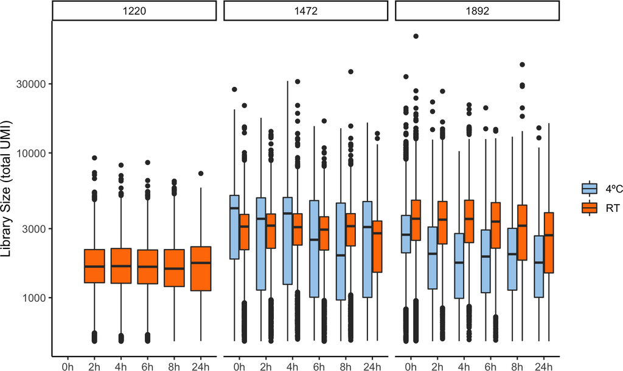

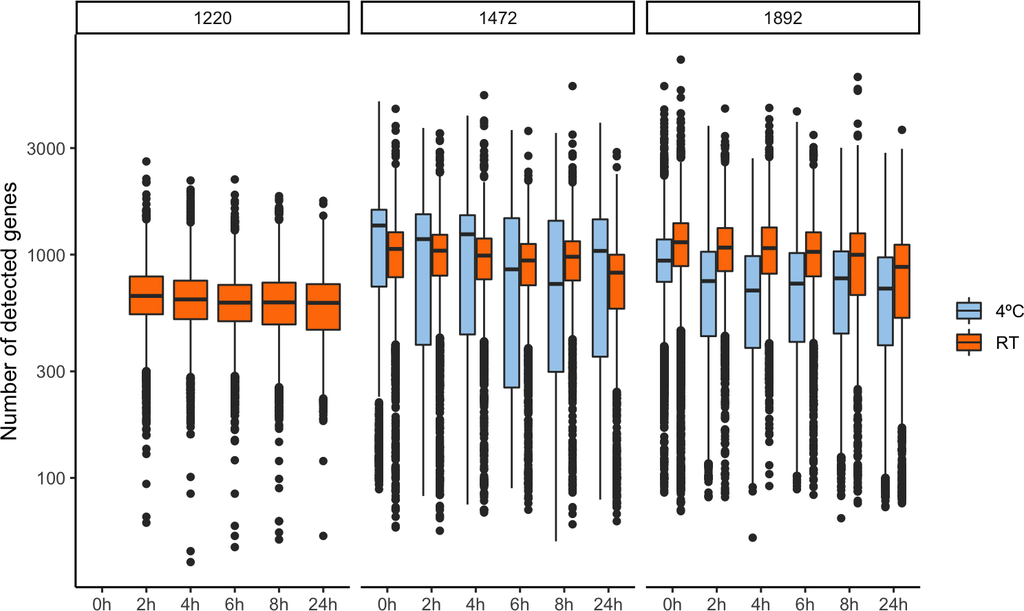

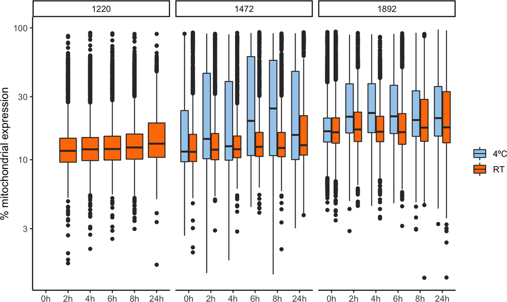

```r
cll_seu$time <- factor(cll_seu$time, levels = c("0h", "2h", "4h", "6h", "8h", "24h"))
qc_colnames <- c("nCount_RNA", "nFeature_RNA", "percent_mt")
qc_titles <- c("Library Size (total UMI)", "Number of detected genes", "% mitochondrial expression")
qc_all_gg <- map2(qc_colnames, qc_titles, function(metric, title) {
  cll_seu@meta.data %>%
  ggplot(aes_string("time", metric, fill = "temperature")) +
     geom_boxplot() +
     scale_y_log10() +
     scale_fill_manual(values = c("#a5cded", "#FF7B02"), labels = c("4ºC", "RT")) +
     facet_wrap(~donor) +
     labs(x = "", y = title, fill = "") +
     theme_classic2()
})
qc_all_gg
```

Importantly, there are systematic differences in library size and cell coverage (# detected genes) between the donor 1220 and the other two (1472, 1892). Thus, we will use donor 1220-specific thresholds for all but mitochondrial expression. Finally, although there are differences between 4ºC and RT, the distributions show a large degree of overlapping, so we will analyse them together.

## 3.3 Joint distribution

Another important exploratory analysis is the joint distribution between the 3 metrics. Specially, a high mitochondrial expression can also be present in metabolically active cells. Therefore, we need to assess how this covaries with total counts. If we find that most cells with large mitochondrial activity also have few genes/UMI, then we can be certain that they are of poor-quality:

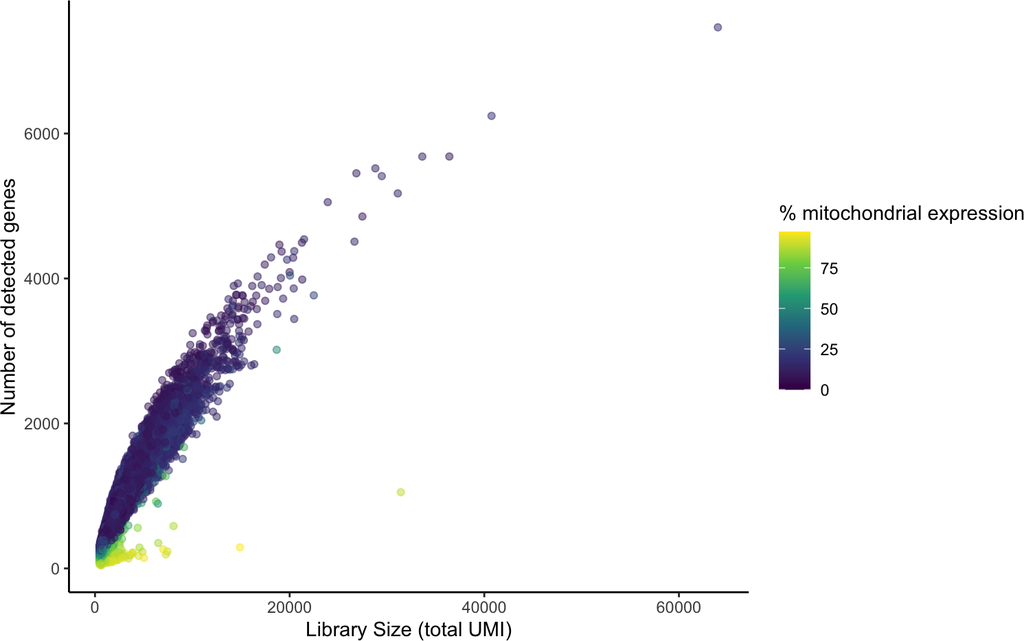

```r
joint_qc_gg <- cll_seu@meta.data %>%
  ggplot(aes(nCount_RNA, nFeature_RNA, color = percent_mt)) +
    geom_point(alpha = 0.5) +
    scale_color_viridis_c() +
    labs(x = qc_titles[1], y = qc_titles[2], color = qc_titles[3]) +
    theme_classic()
joint_qc_gg
```

Indeed, we see that cells with high mitochondrial activity are enriched in the region of low number of UMI and genes. Thus, we can filter them confidently. Noteworthy, there are some cells that are clear outliers in library size and cell coverage and most likely represent doublets.

## 3.4 Thresholds

Now that we have a better appreciation for our data, we can proceed to decide on the thresholds for each metric. We will do so by plotting a histogram for each metric:

### 3.4.1 Library size

```
## $`with 1220`
```

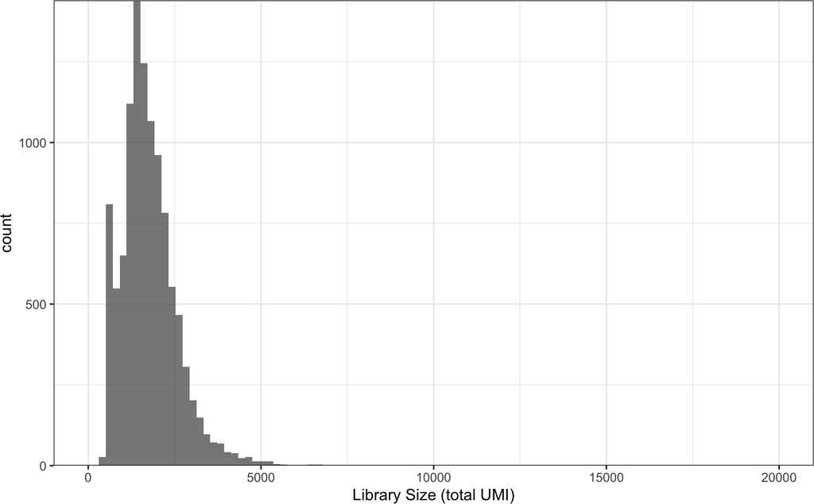

```
##
## $`without 1220`
```

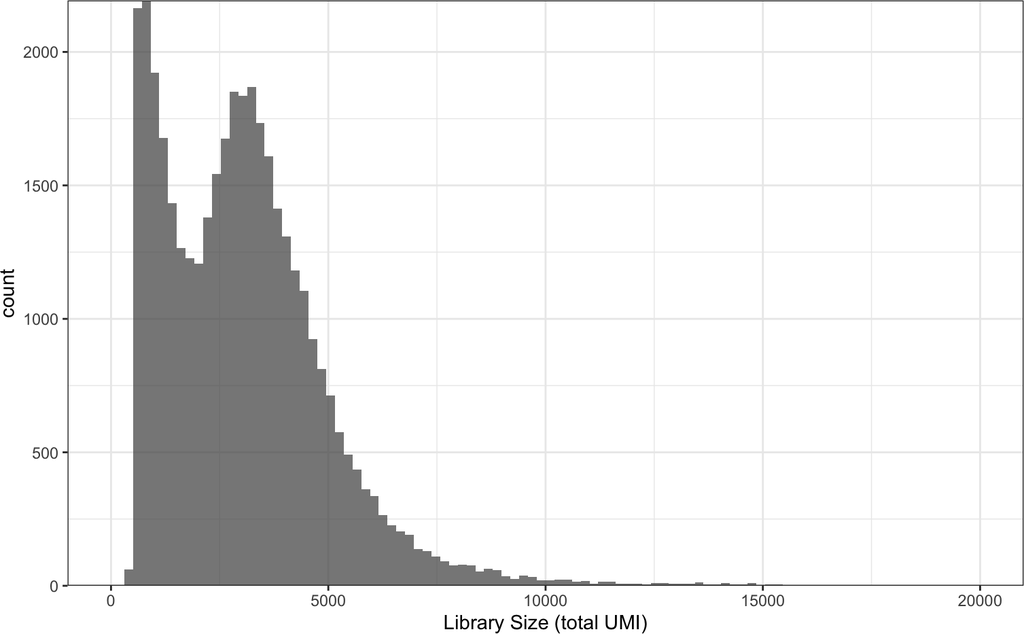

```r
cll_1220 <- subset(cll_seu, subset = donor == "1220")
cll_without_1220 <- subset(cll_seu, subset = donor != "1220")
hist_counts_gg1 <- map(list(cll_1220, cll_without_1220), function(seurat) {
  plot_histogram_seurat(
  seurat,
  qc_metric = qc_colnames[1],
  limits = c(0, 20000),
  title = qc_titles[1],
  log_scale = FALSE
  )
})
names(hist_counts_gg1) <- c("with 1220", "without 1220")
hist_counts_gg1
```

As there is a long tail, we need more resolution to decide on the thresholds:

```
## $`with 1220`
```

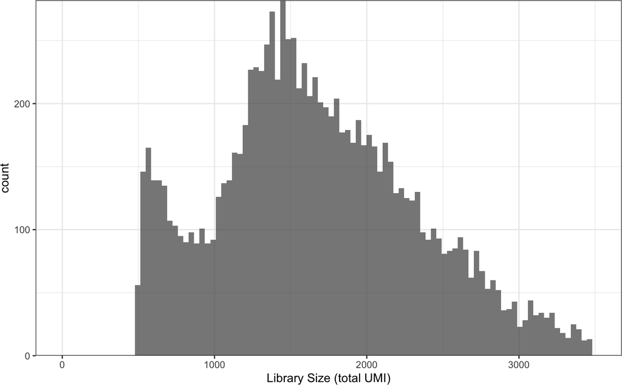

```
##
## $`without 1220`
```

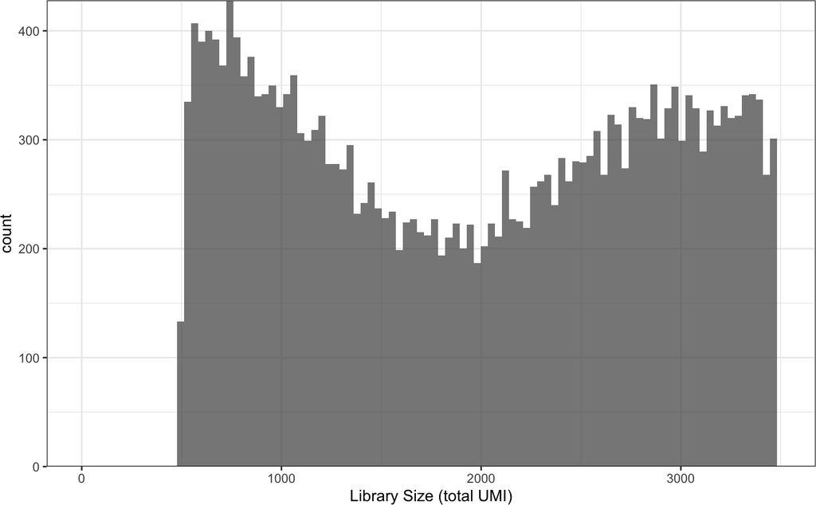

```r
hist_counts_gg2 <- map(list(cll_1220, cll_without_1220), function(seurat) {
  plot_histogram_seurat(
  seurat,
  qc_metric = qc_colnames[1],
  limits = c(0, 3500),
  title = qc_titles[1],
  log_scale = FALSE
  )
})
names(hist_counts_gg2) <- c("with 1220", "without 1220")
hist_counts_gg2
```

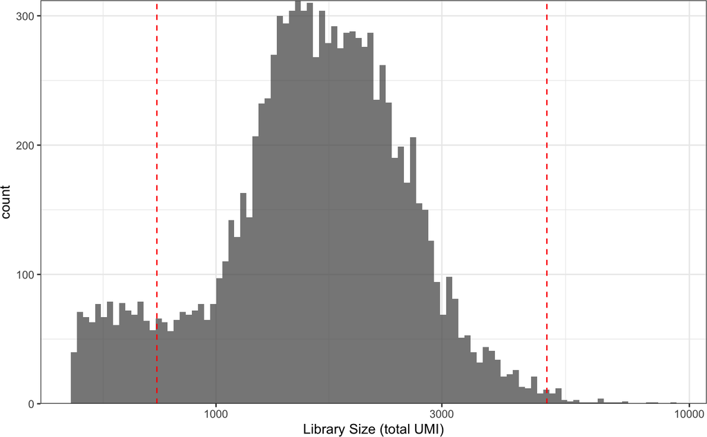

```r
hist_counts_gg3 <- map(list(cll_1220, cll_without_1220), function(seurat) {
  plot_histogram_seurat(
  seurat,
  qc_metric = qc_colnames[1],
  limits = c(0, 20000),
  title = qc_titles[1],
  log_scale = TRUE
  )
})
names(hist_counts_gg3) <- c("with 1220", "without 1220")
hist_counts_gg3$`with 1220` +
  geom_vline(xintercept = min_total_counts_1220, linetype = "dashed", color = "red") +
  geom_vline(xintercept = max_total_counts_1220, linetype = "dashed", color = "red")
```

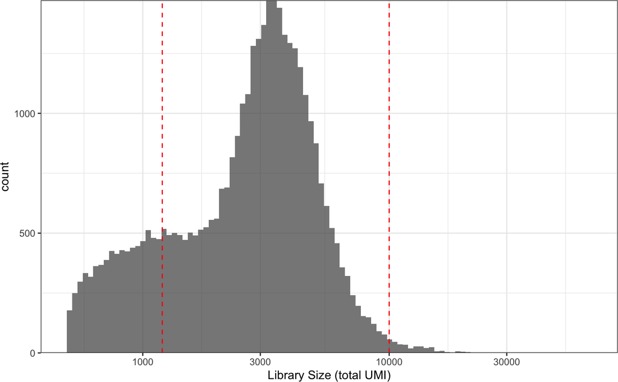

```r
hist_counts_gg3$`without 1220` +
  geom_vline(xintercept = min_total_counts_no_1220, linetype = "dashed", color = "red") +
  geom_vline(xintercept = max_total_counts_no_1220, linetype = "dashed", color = "red")
```

### 3.4.2 Number of detected genes

```
## $`with 1220`
```

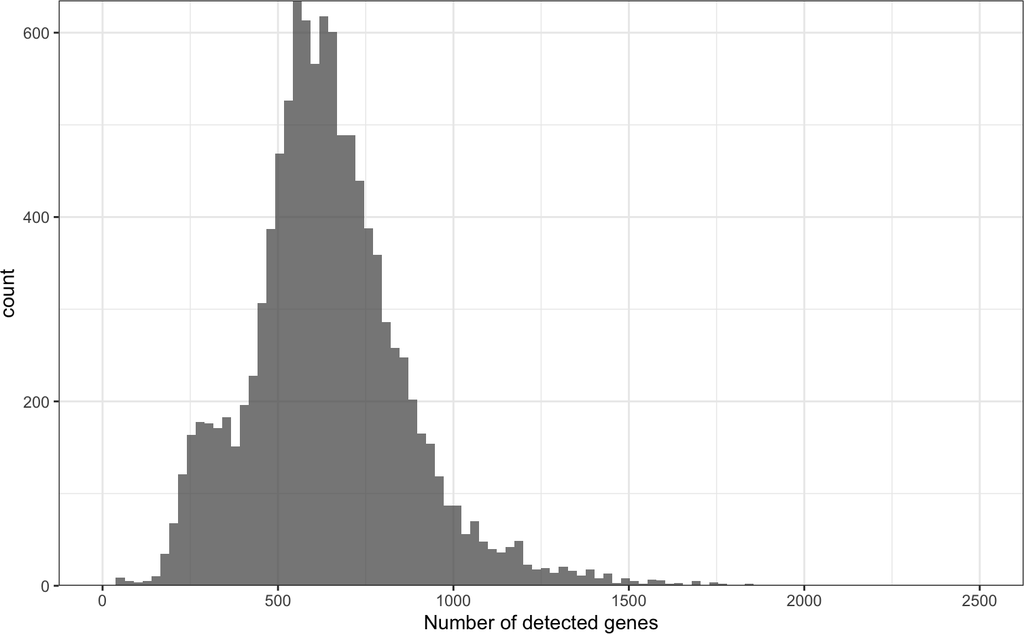

```
##
## $`without 1220`
```

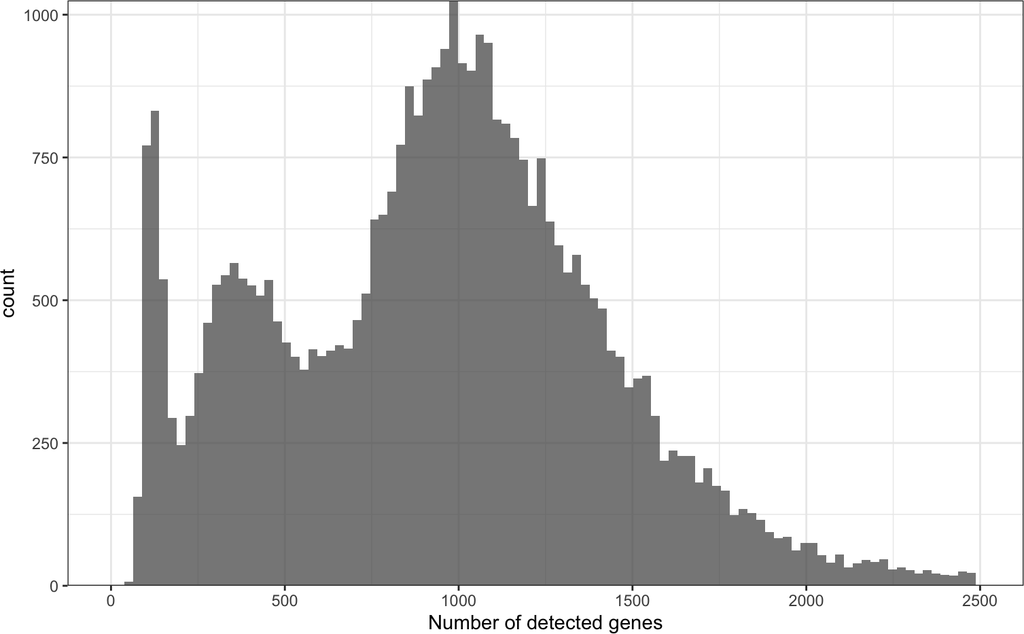

```r
hist_n_genes_gg1 <- map(list(cll_1220, cll_without_1220), function(seurat) {
  plot_histogram_seurat(
  seurat,
  qc_metric = qc_colnames[2],
  limits = c(0, 2500),
  title = qc_titles[2],
  log_scale = FALSE
  )
})
names(hist_n_genes_gg1) <- c("with 1220", "without 1220")
hist_n_genes_gg1
```

For 1220 the distribution is bimodal, so we can assume the first peak to be stressed cells. However, the second has 3 modes, with the 2nd and 3rd peak being potential subpopulations.

We use the following thresholds

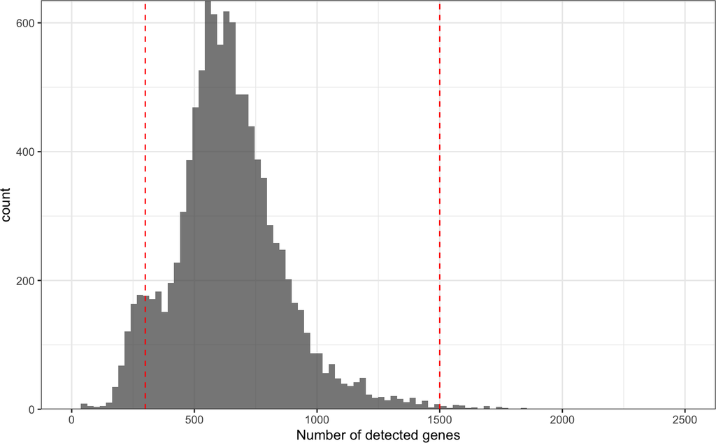

```r
hist_n_genes_gg1$`with 1220` +
  geom_vline(xintercept = min_total_genes_1220, linetype = "dashed", color = "red") +
  geom_vline(xintercept = max_total_genes_1220, linetype = "dashed", color = "red")
```

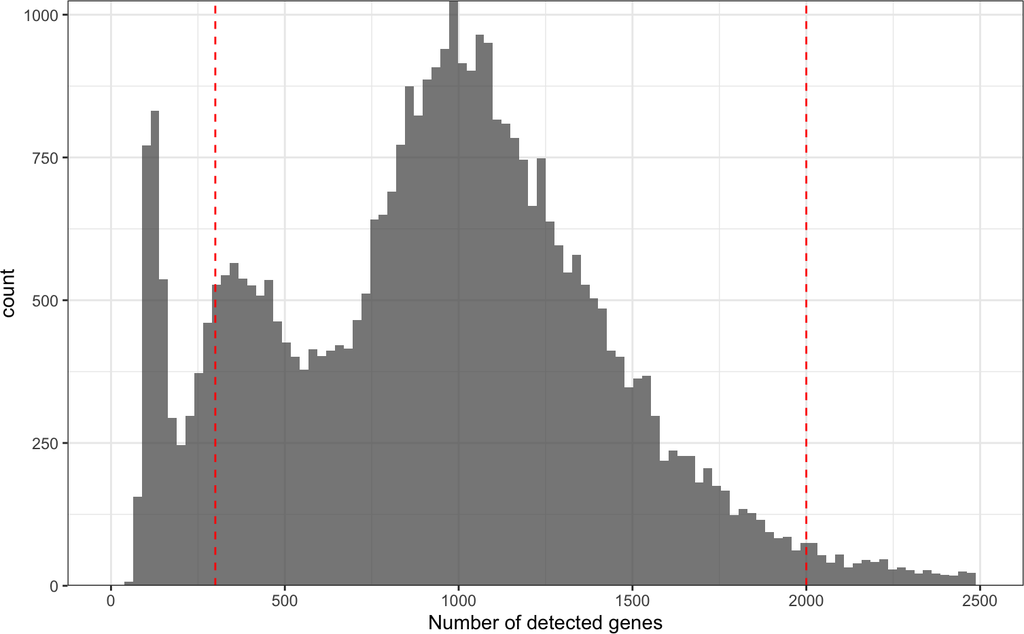

```r
hist_n_genes_gg1$`without 1220` +
  geom_vline(xintercept = min_total_genes_no_1220, linetype = "dashed", color = "red") +
  geom_vline(xintercept = max_total_genes_no_1220, linetype = "dashed", color = "red")
```

### 3.4.3 Mitochondrial expression

In this case, the distributions were homogeneous between the 3 donors, so we can have a single histogram:

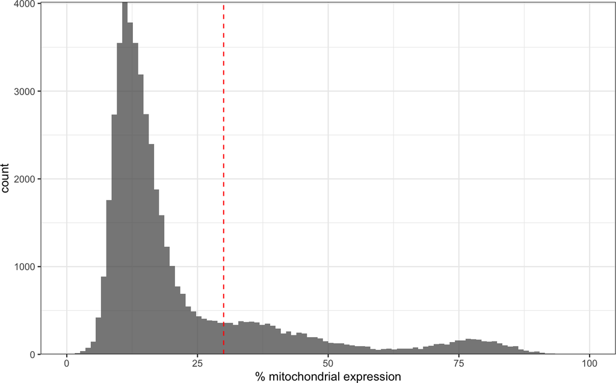

```r
mt_hist <- plot_histogram_seurat(
  cll_seu,
  qc_metric = qc_colnames[3],
  limits = c(0, 100),
  title = qc_titles[3],
  log_scale = FALSE
)
mt_hist +
  geom_vline(xintercept = max_pct_mt_expression, linetype = "dashed", color = "red")
```

Overall, we will consider as poor-quality any cell that satisfies any of the following conditions:

```r
is_poor_quality <-
  (cll_seu$donor == "1220" & cll_seu$nCount_RNA < min_total_counts_1220) |
  (cll_seu$donor == "1220" & cll_seu$nCount_RNA > max_total_counts_1220) |
  (cll_seu$donor != "1220" & cll_seu$nCount_RNA < min_total_counts_no_1220) |
  (cll_seu$donor != "1220" & cll_seu$nCount_RNA > max_total_counts_no_1220) |
  (cll_seu$donor == "1220" & cll_seu$nFeature_RNA < min_total_genes_1220) |
  (cll_seu$donor == "1220" & cll_seu$nFeature_RNA > max_total_genes_1220) |
  (cll_seu$donor != "1220" & cll_seu$nFeature_RNA < min_total_genes_no_1220) |
  (cll_seu$donor != "1220" & cll_seu$nFeature_RNA > max_total_genes_no_1220) |
  cll_seu$percent_mt > max_pct_mt_expression
table(is_poor_quality)
```

```
## is_poor_quality
## FALSE  TRUE
## 37006 12300
```

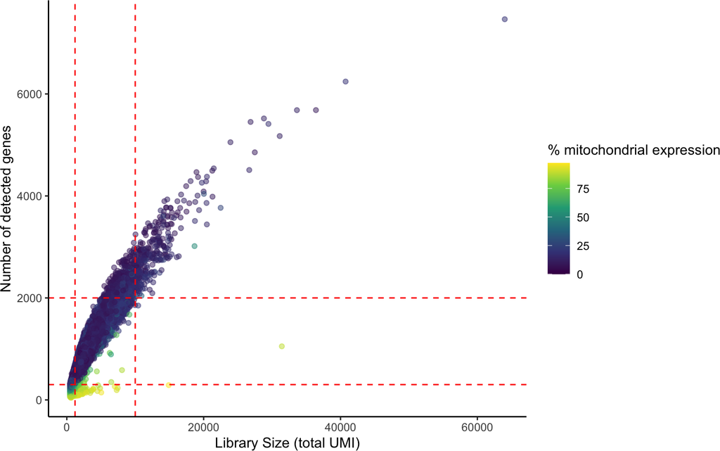

```r
joint_qc_gg +
  geom_vline(xintercept = min_total_counts_no_1220, color = "red", linetype = "dashed") +
  geom_vline(xintercept = max_total_counts_no_1220, color = "red", linetype = "dashed") +
  geom_hline(yintercept = min_total_genes_no_1220, color = "red", linetype = "dashed") +
  geom_hline(yintercept = max_total_genes_no_1220, color = "red", linetype = "dashed")
```

## 3.5 Distribution poor-quality cells across conditions

Of note, we can compare the proportion of poor quality cells across conditions

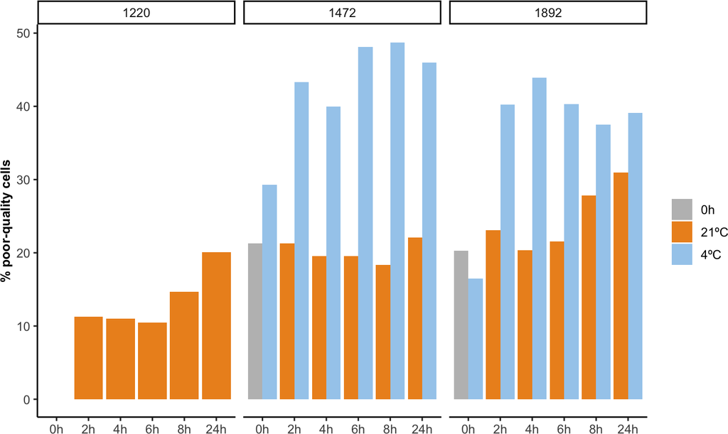

```r
cll_seu$is_low_quality <- is_poor_quality
qc_df <- cll_seu@meta.data
qc_df$temperature <- case_when(
  qc_df$temperature == "4C" ~ "4ºC",
  qc_df$temperature == "RT" & qc_df$time == "0h" ~ "0h",
  qc_df$temperature == "RT" & qc_df$time != "0h" ~ "21ºC"
)
qc_df <- qc_df %>%
  mutate(time = factor(time, levels = c("0h", "2h", "4h", "6h", "8h", "24h")),
         temperature = factor(temperature, levels = c("0h", "21ºC", "4ºC")),
         donor = factor(donor, levels = c("1220", "1472", "1892"))) %>%
  group_by(donor, temperature, time) %>%
  summarise(pct_poor_cells = mean(is_low_quality) * 100,
            num_cells_before_qc = n(),
            average_library_size = mean(nCount_RNA),
            average_num_detected_genes = mean(nFeature_RNA),
            average_mitochondrial_fraction = mean(percent_mt))
poor_cond_gg <- qc_df %>%
  ggplot(aes(time, pct_poor_cells, fill = temperature)) +
    geom_col(position = "dodge") +
    facet_wrap(~donor) +
    scale_fill_manual("", values = c("gray", "#ed9121", "#a5cded")) +
    labs(x = "", y = "% poor-quality cells", color = "") +
    theme_classic2() +
    theme(axis.title.y = element_text(face = "bold", size = 10))
poor_cond_gg
```

```r
col_sel <- c("time", "temperature", "donor", "num_cells_before_qc",
             "average_library_size", "average_num_detected_genes",
             "average_mitochondrial_fraction")
qc_df <- qc_df[, col_sel]
DT::datatable(qc_df)
```

|  | time | temperature | donor | num_cells_before_qc | average_library_size | average_num_detected_genes | average_mitochondrial_fraction |
| --- | --- | --- | --- | --- | --- | --- | --- |
| 1 | 2h | 21ºC | 1220 | 2451 | 1771.32027743778 | 678.075479396165 | 14.1853483439593 |
| 2 | 4h | 21ºC | 1220 | 2659 | 1779.37044001504 | 650.588943211734 | 14.3266559484432 |
| 3 | 6h | 21ºC | 1220 | 2326 | 1752.24204643164 | 626.469045571797 | 14.6801882426717 |
| 4 | 8h | 21ºC | 1220 | 2392 | 1727.55518394649 | 625.840301003345 | 15.7582801521139 |
| 5 | 24h | 21ºC | 1220 | 932 | 1755.90772532189 | 609.459227467811 | 17.5707156572572 |
| 6 | 0h | 0h | 1472 | 1716 | 3022.99475524476 | 1006.84440559441 | 18.1641649363765 |
| 7 | 2h | 21ºC | 1472 | 1317 | 3092.0106302202 | 996.839787395596 | 18.8359656474643 |
| 8 | 4h | 21ºC | 1472 | 1165 | 3149.01287553648 | 971.272961373391 | 18.4449119551248 |
| 9 | 6h | 21ºC | 1472 | 1325 | 2916.22716981132 | 904.838490566038 | 19.0841048890317 |
| 10 | 8h | 21ºC | 1472 | 1293 | 3121.66666666667 | 946.431554524362 | 18.7578467735118 |

[output cut: 19 more lines]

```r
# saveRDS(qc_df, file = "results/R_objects/qc_summary_table_cll.rds")
```

We observe that, in general, 4ºC cells have a lower quality than those at RT.

## 3.6 Cell filtering

In light of the above, we will discard 12300 cells:

```r
table(is_poor_quality)
```

```
## is_poor_quality
## FALSE  TRUE
## 37006 12300
```

```r
cll_seu <- subset(cll_seu, subset = is_low_quality == FALSE)
cll_seu
```

```
## An object of class Seurat
## 33567 features across 37006 samples within 2 assays
## Active assay: RNA (33538 features)
##  1 other assay present: HTO
```

# 4 Gene QC

Let us compute the number of cells expressing each gene:

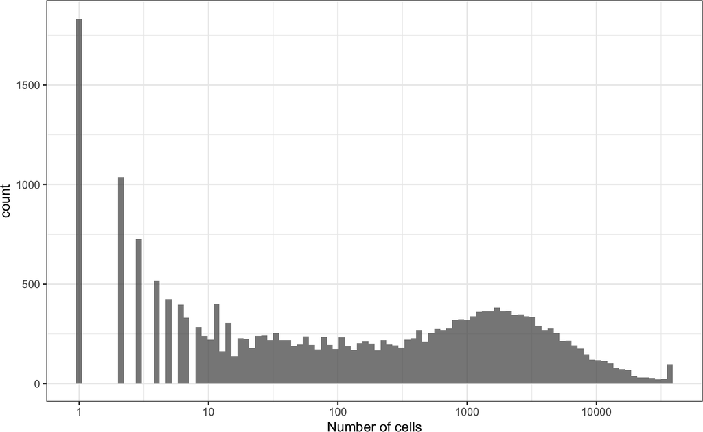

```r
n_cells <- rowSums(as.matrix(cll_seu[["RNA"]]@counts) > 0)
gene_qc_gg <- n_cells %>%
  as.data.frame() %>%
  ggplot(aes(n_cells)) +
    geom_histogram(bins = 100, alpha = 0.75) +
    scale_x_log10("Number of cells") +
    theme_bw()
gene_qc_gg
```

We see two peaks, the first one of which corresponds to lowly expressed genes. As explained in [Luecken MD *et al*.](https://www.embopress.org/doi/pdf/10.15252/msb.20188746): “a guideline to setting this threshold is to use the minimum cell cluster size that is of interest and leaving some leeway for dropout effects”. As we will not rely on clusters that have fewer than 15 cells, we will use it as a filter:

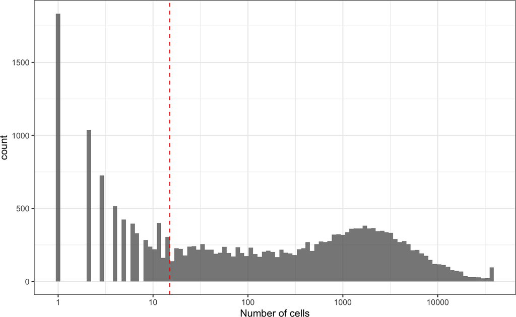

```r
gene_qc_gg +
  geom_vline(xintercept = min_total_cells, color = "red", linetype = "dashed")
```

```r
cll_sce <- as.SingleCellExperiment(cll_seu)
cll_sce <- cll_sce[n_cells > 15, ]
cll_sce
```

```
## class: SingleCellExperiment
## dim: 15710 37006
## metadata(0):
## assays(2): counts logcounts
## rownames(15710): AL627309.1 AL669831.5 ... AC004556.1 AC240274.1
## rowData names(0):
## colnames(37006): 1472_RT_AAACCCAAGTGGATTA-1 1472_RT_AAACCCACACTACAGT-1 ... 1220_RT_TTTGTTGTCACCTCGT-1 1220_RT_TTTGTTGTCGCCTTGT-1
## colData names(12): nCount_RNA nFeature_RNA ... is_low_quality ident
## reducedDimNames(0):
## spikeNames(0):
## altExpNames(0):
```

### 4.0.1 Identify highly expressed genes

As a validation, let us check whether the highest expressed genes are housekeeping genes like ACTB:

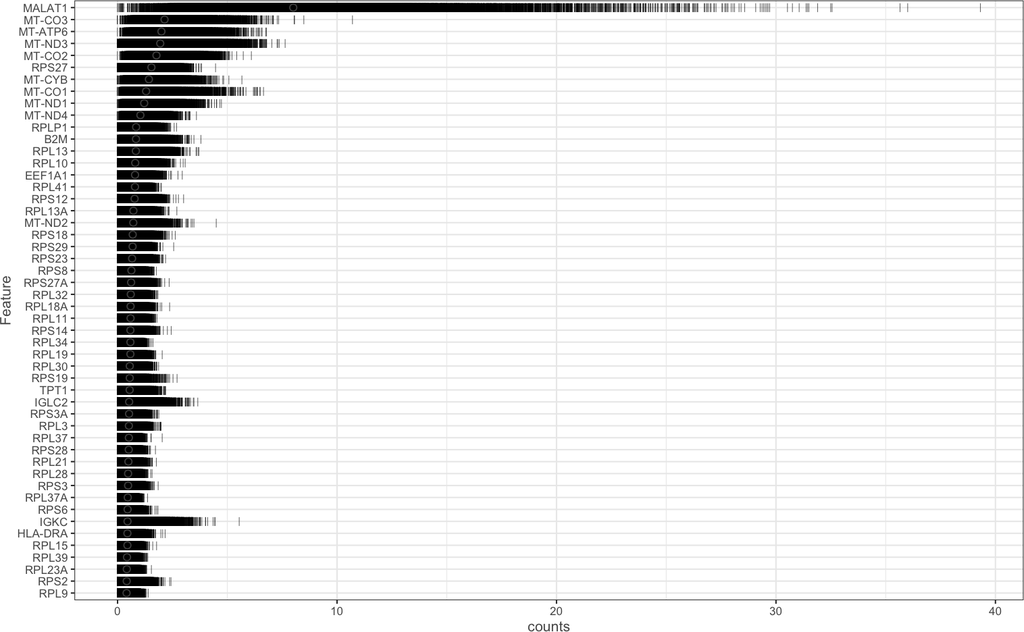

```r
row_data_frame <- data.frame(symbol = rownames(cll_sce))
rownames(row_data_frame) <- rownames(cll_sce)
rowData(cll_sce) <- row_data_frame
cll_sce <- calculateQCMetrics(cll_sce)
plotHighestExprs(cll_sce, feature_names_to_plot = "symbol")
```

# 5 Normalization

To confidently compare gene expression between cells, we need to correct for two biases:

- Differences in library size: if one cell has more total counts than another due to sampling effects, genes that are equally expressed will show up as upregulated.
- Between-sample systematic biases: if two conditions/donors were sequenced at different depths or in different batches, there might be compositional biases between conditions that yield a systematic up- or down-regulation.

To correct for both, we will use the [`scran` package](https://genomebiology.biomedcentral.com/articles/10.1186/s13059-016-0947-7), as according to both [Vieth B, *et al*](https://www.nature.com/articles/s41467-019-12266-7) and [Vallejos CA, *et al*.](https://www.nature.com/articles/nmeth.4292), it is the most robust method for scRNA-seq data normalization:

```r
cll_sce <- computeSumFactors(cll_sce)
summary(sizeFactors(cll_sce))
```

```
##    Min. 1st Qu.  Median    Mean 3rd Qu.    Max.
##  0.1692  0.6413  0.9276  1.0000  1.2775  3.1275
```

```r
assays(cll_sce)
```

```
## List of length 2
## names(2): counts logcounts
```

```r
logcounts(cll_sce)[1:6, 1:6]
```

```
## 6 x 6 sparse Matrix of class "dgCMatrix"
##            1472_RT_AAACCCAAGTGGATTA-1 1472_RT_AAACCCACACTACAGT-1 1472_RT_AAACCCACACTGGCGT-1 1472_RT_AAACCCACAGCTCGGT-1 1472_RT_AAACCCACATTGACCA-1 1472_RT_AAACCCATCCCTCATG-1
## AL627309.1                          .                   .                                 .                          .                          .                          .
## AL669831.5                          .                   1.016221                          .                          .                          .                          .
## LINC00115                           .                   .                                 .                          .                          .                          .
## FAM41C                              .                   .                                 .                          .                          .                          .
## NOC2L                               .                   .                                 .                          .                          .                          .
## KLHL17                              .                   .                                 .                          .                          .                          .
```

Let us assess if the size factors correlate with the library size:

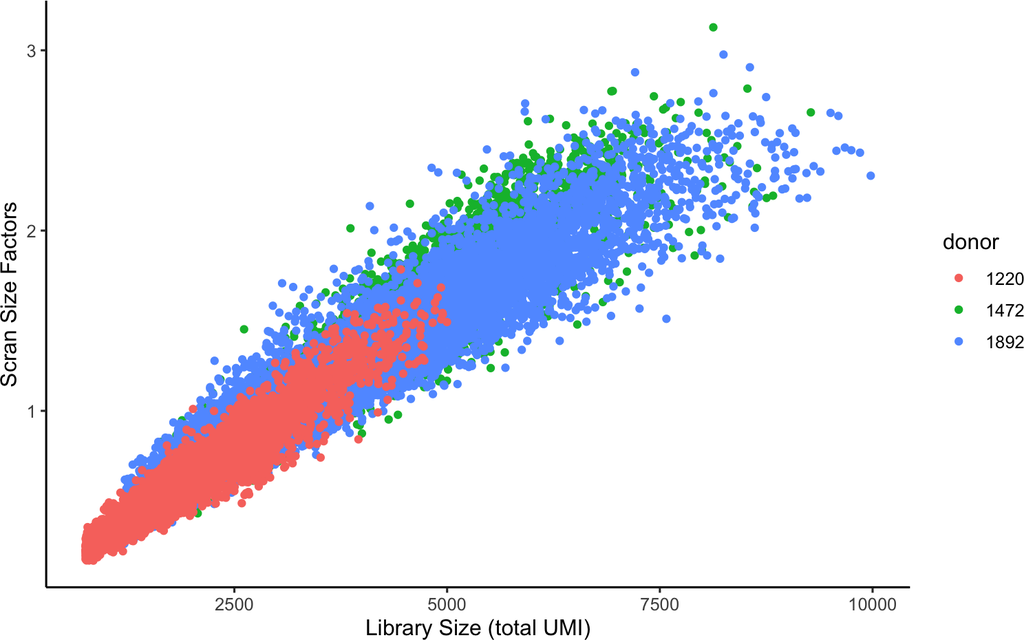

```r
size_fact_df <- data.frame(
  lib_size = cll_sce$nCount_RNA,
  size_fact = sizeFactors(cll_sce),
  donor = cll_sce$donor
)
ggplot(size_fact_df, aes(lib_size, size_fact, color = donor)) +
  geom_point() +
  labs(x = "Library Size (total UMI)", y = "Scran Size Factors") +
  theme_classic2()
```

```r
lm_size_fact <- lm(size_fact ~ lib_size, data = size_fact_df)
summary(lm_size_fact)
```

```
##
## Call:
## lm(formula = size_fact ~ lib_size, data = size_fact_df)
##
## Residuals:
##      Min       1Q   Median       3Q      Max
## -0.89670 -0.06464 -0.00969  0.05645  0.82936
##
## Coefficients:
##              Estimate Std. Error t value Pr(>|t|)
## (Intercept) 1.405e-02  1.524e-03   9.225   <2e-16 ***
## lib_size    3.158e-04  4.445e-07 710.514   <2e-16 ***
## ---
## Signif. codes:  0 '***' 0.001 '**' 0.01 '*' 0.05 '.' 0.1 ' ' 1
##
## Residual standard error: 0.121 on 37004 degrees of freedom
## Multiple R-squared:  0.9317, Adjusted R-squared:  0.9317
## F-statistic: 5.048e+05 on 1 and 37004 DF,  p-value: < 2.2e-16
```

As we can see, 93.170604 of the variation in scran’s size factors is explained by the library size, so we can conclude that there is a strong positive correlation between both. Moreover, the remaining variation (scatter along the regression line) is explained by the different donor. As we saw above, donors 1472 and 1892 were deeper sequenced than 1220. All in all, this validates that scran is normalizing by the two major biases explained above.

# 6 Save Seurat object

Finally, we can convert it back to seurat and save it as a compressed .RDS file for future analysis:

```r
cll_seu <- as.Seurat(cll_sce)
# saveRDS(cll_seu, "results/R_objects/cll_seurat_filtered_normalized.rds")
```